# DESeq2-MultiBatch: Batch Correction for Multi-Factorial RNA-seq Experiments

Julien Roy

2025-09-08

# Abstract

In this document, we will explore the experimental design as shown in “DESeq2-MultiBatch: Batch Correction for Multi-Factorial RNA-seq Experiments”.

The first part will explain how the batch factor affects results and show in detail how to take the its effect into account. To obtain corrected counts for downstream analysis or visualizations, the DESeq2-MultiBatch will be applied and compared with limma’s RemoveBatchEffects and Combat_seq.

The second part will provide recommendations and practical strategies for performing DESeq2 analyses with complex experimental designs. It includes specific guidance on constructing design matrices, addressing imbalanced datasets, defining appropriate contrasts, and conducting multi-factorial analyses with illustrative examples.

For more information about DESeq2 and the standard RNA-seq analysis steps, refer to:

- [Analyzing RNA-seq data with DESeq2](https://bioconductor.org/packages/release/bioc/vignettes/DESeq2/inst/doc/DESeq2.html) (Love & al., 2025)
- [RNA-seq workflow: gene-level exploratory analysis and differential expression](https://bioconductor.org/packages/release/workflows/vignettes/rnaseqGene/inst/doc/rnaseqGene.html) (Love & al., 2019)

# Context and initial DESeq2 setup

## Experimental design

The simulated dataset used in this study consists of 1,000 genes across 48 samples.

The experimental design involves two batches, modeling gene expression in dioecious plants (e.g., XX/XY system) undergoing sex-specific treatments at two distinct time points: Day 0 (vegetative) and Day 1 (early flowering). Due to sex-specific treatments to alter flower sex, male and female plants were separated across batches:

Batch A: Female controls (n=6) and treated males (n=6)

Batch B: Male controls (n=6) and treated females (n=6)

The treatments were applied following Day 0 measurements but before Day 1 measurements, allowing Day 0 data to serve as a baseline for controlling batch effects.

Samples were collected across two genotypes, with three biological replicates per combination of sex, treatment, genotype, batch and time point.

Additionally, the length of photoperiod is changed in-between Day 0 and Day 1 to induce flowering. We can refer to Day 0 samples as “vegetative” and Day 1 samples as “early flowering”.

An overview of the experimental setup is seen below. Note that it does not include the genotype information for simplicity.

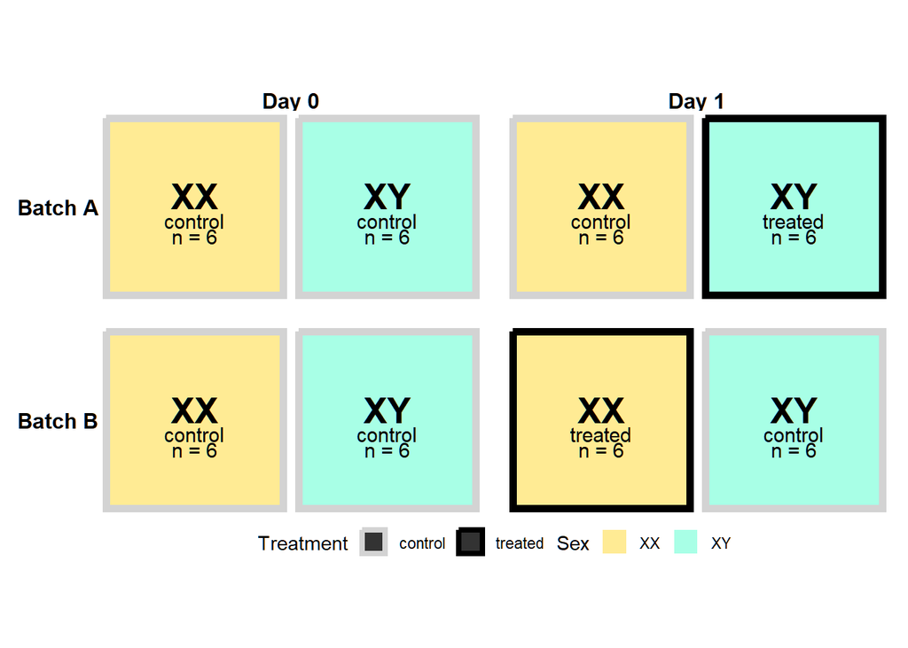

We could use the data to look at :

1. The main effects of interest in this study, which are the treatments;
2. Sex differences in gene expression for vegetative plants (“xx day 0 control” v. “xy day 0 control”);
3. Sex differences in gene expression in early-flowering plants (“xx day 1 control” v. “xy day 1 control”);
4. Change in gene expression induced by the change in photoperiod for both sexes (biologically, we expect different effects on females and males);
5. Genotype differences in gene expression (intra-species variability);
6. Differential effect of treatment across genotypes (variability of treatment response).

These will be discussed in Part 2

## Loading data files

```r
# load metadata
colData <- read.csv(file = "coldata.csv")
colData[,2:6] <- lapply(colData[,2:6], as.factor)

# load counts
counts <- read.csv(file = "counts.csv", check.names = FALSE, row.names = 1)
```

Samples are rows in the ColData, with factors as columns. In the count file, rows are genes with samples as columns.

| SampleID | Genotype | Sex | Day | Batch | Treatment |
| --- | --- | --- | --- | --- | --- |
| Sample1 | c1 | xx | 0 | a | ctrl |
| Sample2 | c1 | xx | 0 | a | ctrl |
| Sample3 | c1 | xx | 0 | a | ctrl |
| Sample4 | c2 | xx | 0 | a | ctrl |
| Sample5 | c2 | xx | 0 | a | ctrl |
| Sample6 | c2 | xx | 0 | a | ctrl |
| Sample7 | c1 | xy | 0 | a | ctrl |
| Sample8 | c1 | xy | 0 | a | ctrl |
| Sample9 | c1 | xy | 0 | a | ctrl |
| Sample10 | c2 | xy | 0 | a | ctrl |

[output cut: 38 more lines]

As you can see, the treatments are denoted “treat1” and “treat2”. It could be simply “treat”, but it would require the interaction “Treatment:Sex” to allow for independent effects of masculinisation and feminisation.

## Exploratory analysis and visualization

To view the relationship between sample groups a simple *dds* object is first created.

The factors included in the design used for the basic DESeq2 analysis assume no batch effects and does not bother about genotypes (yet).

```r
# design
design <- ~ Day + Sex + Sex:Day + Treatment

# construct a DESeqDataSet object
dds <- DESeqDataSetFromMatrix(countData = counts,
                                  colData = colData,
                                  design = design)

dds <- DESeq(dds)

resultsNames(dds)
```

```
## [1] "Intercept"                "Day_1_vs_0"
## [3] "Sex_xy_vs_xx"             "Treatment_treat1_vs_ctrl"
## [5] "Treatment_treat2_vs_ctrl" "Day1.Sexxy"
```

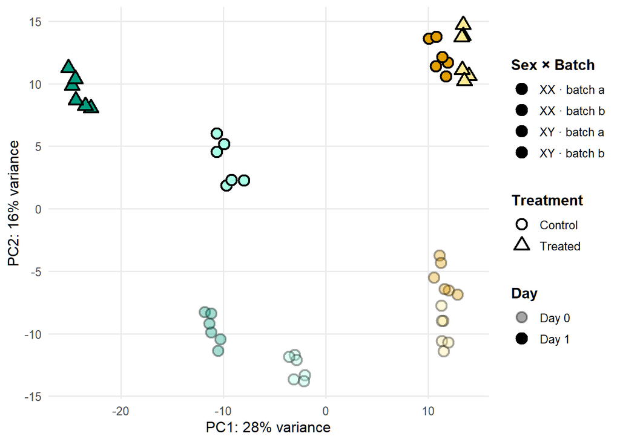

Using **intgroup = c(“Sex”, “Day”, “Batch”)**, we can see that female samples at day 0 from both batches do not cluster together. Inferring the effect of treatment simply by comparing treated and control female samples at day 1 would also include the variation from batch effects : we mix true treatment signal with batch shifts.

In our case, these can be caused by the environmental factors from the greenhouses (temperature, humidity, sunlight, etc.) or other sources of variations (personnel, irrigation, handling, etc.).

To understand the approach taken, let’s look at the PCA plot using only XX samples :

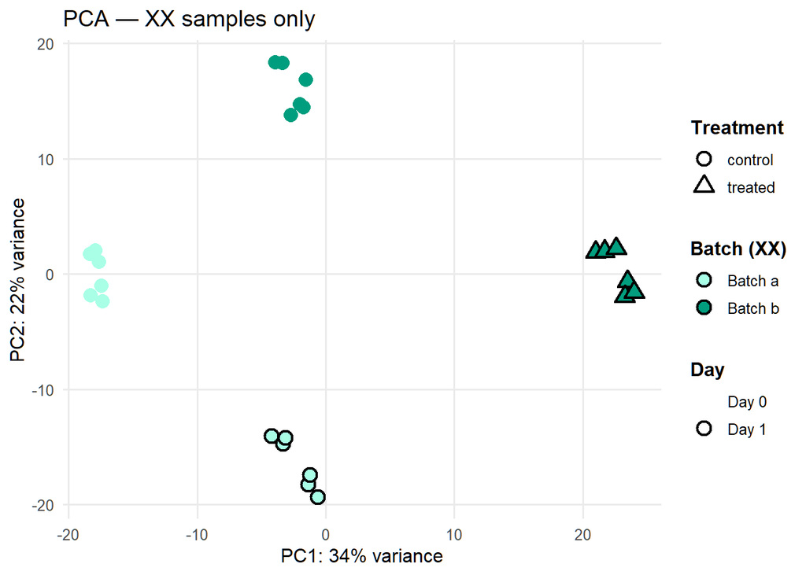

In the PCA above, look at Batch A, where the Day 1 XX samples are controls. Using DESeq2, compute the change in expression from Day 0 to Day 1 within Batch A. This within-batch change reflects only the effect of the photoperiod change, because no treatment was applied to XX in Batch A at Day 1.

Next, look at Batch B, where the Day 1 XX samples received the treatment. Compute the change in expression from Day 0 to Day 1 within Batch B. This within-batch change reflects the combined effect of the day transition and the treatment.

Finally, subtract the Batch A change from the Batch B change. The remainder isolates the treatment effect in XX at Day 1, with the batch effect removed. On the log2 fold-change scale used by DESeq2, this is implemented as a simple subtraction of the relevant model coefficients or contrasts.

Of course, the PCA is helpful the visualize group clustering, but it does not, by itself, provide useful distances for gene expression. This is done by DESeq2.

Now, let’s look at the PCA plot using only day 0 samples, which are all control samples, without photoperiod change nor treatment, to get an overview of the batch effect.

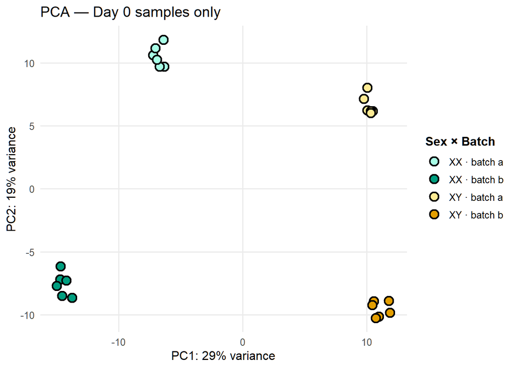

Batch effects are sizable, with samples from the same batch and sex clustering very tightly, independently of genotype (not shown here). It seems like the variation explained by the sex is on the same scale as the variation caused by batch.

The next step would be to consider including a *batch* factor in the analysis. However, this assumes that the change in gene expression are similar for female and male plants. There are numerous reasons why dioecious plants might behave differently if the growth conditions from the greenhouse or other factors are important. For example, if this study was conducted at two separate moments in the year, batch effects would include seasonal changes.

It is possible to quantify the degree of similarity of batch effects on female and male plants by either looking at the residual distances when correcting for a single batch factor, or by plotting the log 2 fold changes caused by batch effect in female and males of all genes.

First, lets take as an example a gene that shows an interesting behaviour.

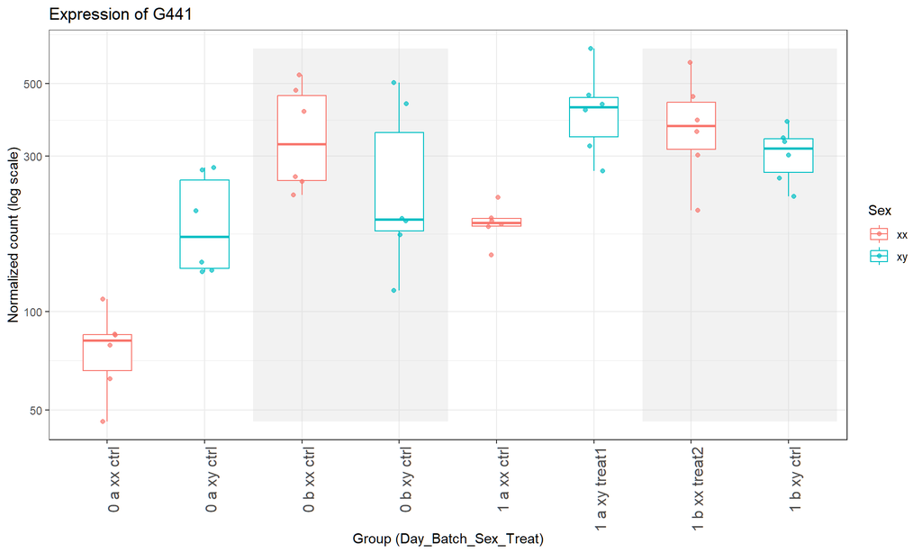

At day 0, we can see that the XX samples from batch B (3rd column) have higher counts than their counterparts from batch A (1st column), even if both of the groups are controls.

Inversely, the male samples show uniform expression values across batches at day 0 (column 2 and 4).

For our study, we would be trying to extract the effect of treatment.

Lets look at the data for XX samples as seen by DESeq2 if we exclude the batch factor.

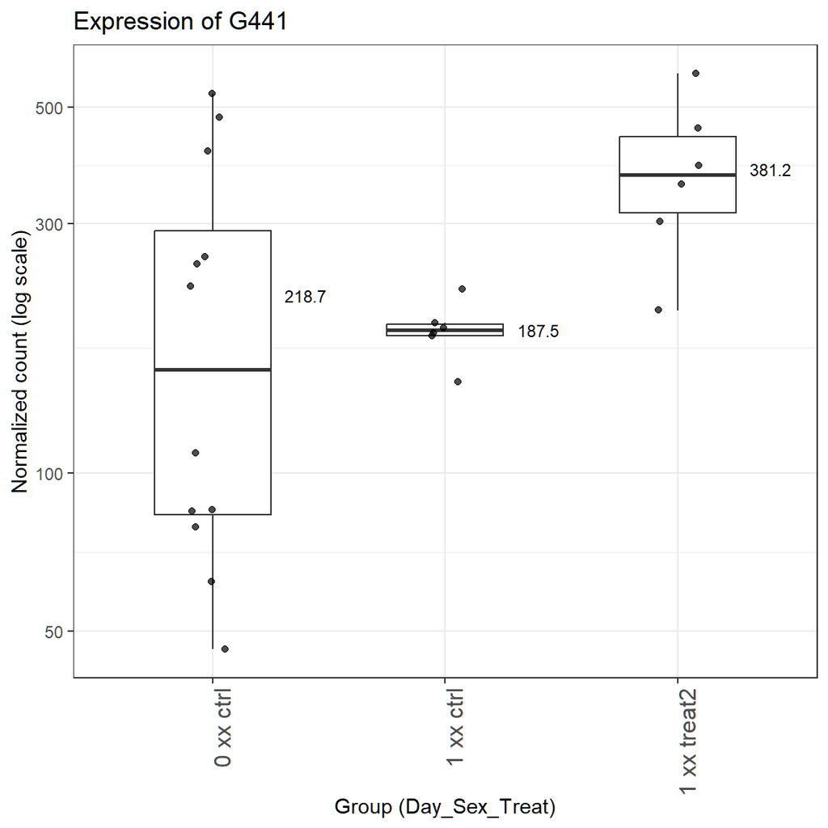

As a reminder, the design used for this *dds* object is *~ Day + Sex + Sex:Day + Treatment*

We can see that DESeq2 would use **all** XX controls at day 0 to find a baseline expression value, then would compare this value with the XX control samples at day 1 to get the effect of photoperiod change (day).

Then, the model compares XX treated and XX control samples at day 1 to get the effect of treatment on female plants.

Here, with the average expression shown, we can already predict that the effect of the photoperiod change (control XX at day 1 v. control XX at day 0) will be minimal (LFC < 0 but close to 0).

The effect of the treatment will be roughly LFC = 1 (the expression approximately doubles from 187.5 to 381.2).

```r
day_effect <- results(dds, name = "Day_1_vs_0", independentFiltering = FALSE)
day_effect[441,]
```

```
## log2 fold change (MLE): Day 1 vs 0
## Wald test p-value: Day 1 vs 0
## DataFrame with 1 row and 6 columns
##       baseMean log2FoldChange     lfcSE      stat    pvalue      padj
##      <numeric>      <numeric> <numeric> <numeric> <numeric> <numeric>
## G441   274.793      -0.222236   0.35331 -0.629011  0.529342  0.667518
```

```r
trt2_effect <- results(dds, name = "Treatment_treat2_vs_ctrl", independentFiltering = FALSE)
trt2_effect[441,]
```

```
## log2 fold change (MLE): Treatment treat2 vs ctrl
## Wald test p-value: Treatment treat2 vs ctrl
## DataFrame with 1 row and 6 columns
##       baseMean log2FoldChange     lfcSE      stat    pvalue      padj
##      <numeric>      <numeric> <numeric> <numeric> <numeric> <numeric>
## G441   274.793        1.02375  0.407072   2.51491 0.0119064 0.0351221
```

As expected, LFCs of about -0.2 and 1 for day and treatment, respectively. The treatment has an effect on gene expression (padj = 0.035).

Now, lets look at the data as seen by DESeq2 if we include the batch factor.

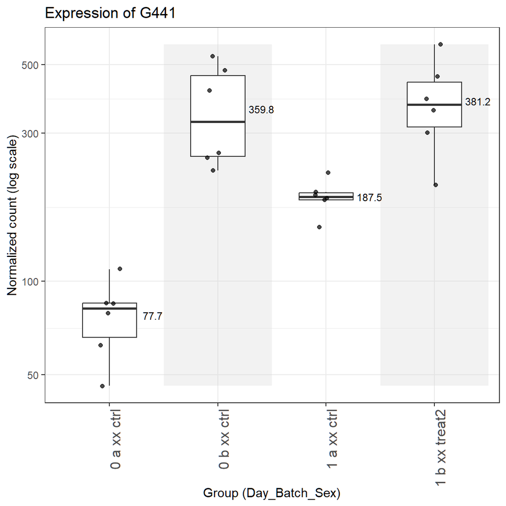

DESeq2 can extract the effect of the change in photoperiod using XX samples from batch A (controls, only received the photoperiod change).

Here, we can approximate this day effect with 188/78 for a LFC of about 1.3.

Then, if we assume that the change in photoperiod affects XX samples the same way across batches, the treatment effect would be the difference between the expected value from XX samples in batch B when the photoperiod effect is applied and the value from treated XX samples.

Let’s apply a LFC of 1.3 to the XX samples from batch B : 360 * 2^1.3 = 886.

In other words, if XX samples from batch B were not treated, we would expect their average expression to be around 886.

The treatment effect would then be the LFC from 886/381, which is about -1.2.

This also assume that there are not interactions between the photoperiod change and the treatment.

Can we get these expected results by adding a batch factor to the design ?

```r
design <- ~ Day + Batch + Sex + Sex:Day + Treatment

dds <- DESeqDataSetFromMatrix(countData = counts,
                                  colData = colData,
                                  design = design)

dds <- DESeq(dds)
day_effect <- results(dds, name = "Day_1_vs_0", independentFiltering = FALSE)
day_effect[441,]
```

```
## log2 fold change (MLE): Day 1 vs 0
## Wald test p-value: Day 1 vs 0
## DataFrame with 1 row and 6 columns
##       baseMean log2FoldChange     lfcSE      stat    pvalue      padj
##      <numeric>      <numeric> <numeric> <numeric> <numeric> <numeric>
## G441   274.793       0.758505  0.313468   2.41972 0.0155325 0.0543872
```

```r
trt2_effect <- results(dds, name = "Treatment_treat2_vs_ctrl", independentFiltering = FALSE)
trt2_effect[441,]
```

```
## log2 fold change (MLE): Treatment treat2 vs ctrl
## Wald test p-value: Treatment treat2 vs ctrl
## DataFrame with 1 row and 6 columns
##       baseMean log2FoldChange     lfcSE      stat    pvalue      padj
##      <numeric>      <numeric> <numeric> <numeric> <numeric> <numeric>
## G441   274.793      -0.308502  0.408033 -0.756071  0.449606  0.666583
```

Instead of 1.3 and -1.2, we get 0.75 and -0.3. This is because the model adjusts for a single batch effect and, for this gene, it is not homogeneous across sex (remember that XY samples had little batch effect for G441).

```r
batch_effect <- results(dds, name = "Batch_b_vs_a", independentFiltering = FALSE)
batch_effect[441,]
```

```
## log2 fold change (MLE): Batch b vs a
## Wald test p-value: Batch b vs a
## DataFrame with 1 row and 6 columns
##       baseMean log2FoldChange     lfcSE      stat      pvalue       padj
##      <numeric>      <numeric> <numeric> <numeric>   <numeric>  <numeric>
## G441   274.793        1.33227  0.236266   5.63883 1.71205e-08 4.7557e-07
```

The single batch effect for this gene is about 1.33.

To help visualize this batch factor, let’s look at the data from day 0, both sexes included, before and after adjusting for a single batch effect of 1.33 :

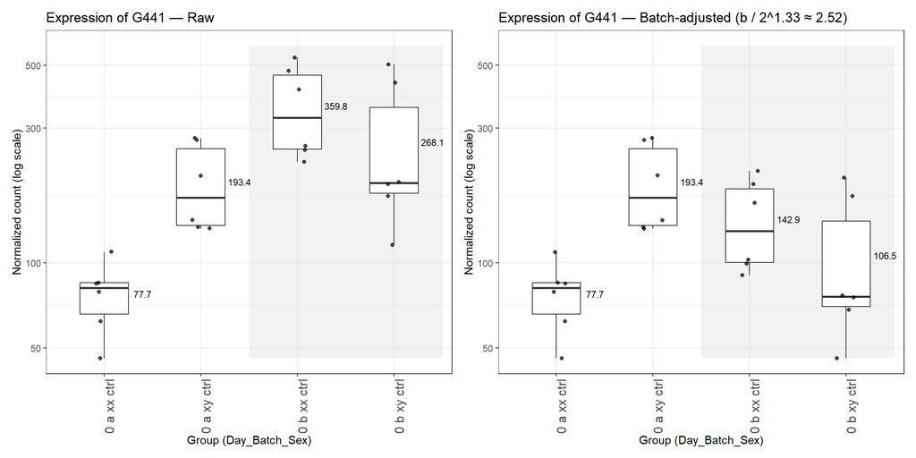

First, looking at the left panel, we can do quick calculations for batch effect for each sex :

XX samples batch effect = 360/78 = 4.6, for a LFC of about **2.2**

XY samples batch effect = 268/193 = 1.4, for a LFC of about **0.5**

Averaging both these LFC yields approximately the previously calculated single batch factor of 1.33

On the right panel, counts are corrected by the batch effect calculated previously by DESeq2 (1.33).

The simple correction of batch B samples by this factor aligns both batches to batch A level (the counts of 78 and 193 are untouched, as they are from the reference level). This assumes that batch A is somehow more representative than batch B. For the real correction we will apply later, this correction is halved and applied to both batch as to find a midway point.

We can see the issue caused by a single batch correction for this specific gene. It aims for similar expression across batches, improving the alignment of counts for xx samples, although there is a remaining difference (78 v. 143). Meanwhile, while XY samples had only slightly different expression levels across batch, the corrected data induces a major change in expression.

Now, let’s look at the last design that includes both a batch factor and an interaction term Sex:Batch, which allows the model to fit a separate effect of batch on XY independently from the effect of batch on XX (base level, which means the batch effect without interaction represent the effect on XX).

```r
design <- ~ Day + Batch + Sex + Sex:Batch + Sex:Day + Treatment

dds <- DESeqDataSetFromMatrix(countData = counts,
                                  colData = colData,
                                  design = design)

dds <- DESeq(dds)
```

```r
day_effect <- results(dds, name = "Day_1_vs_0", independentFiltering = FALSE)
day_effect[441,]
```

```
## log2 fold change (MLE): Day 1 vs 0
## Wald test p-value: Day 1 vs 0
## DataFrame with 1 row and 6 columns
##       baseMean log2FoldChange     lfcSE      stat      pvalue        padj
##      <numeric>      <numeric> <numeric> <numeric>   <numeric>   <numeric>
## G441   274.793        1.27074  0.294593   4.31356 1.60648e-05 0.000254997
```

```r
trt2_effect <- results(dds, name = "Treatment_treat2_vs_ctrl", independentFiltering = FALSE)
trt2_effect[441,]
```

```
## log2 fold change (MLE): Treatment treat2 vs ctrl
## Wald test p-value: Treatment treat2 vs ctrl
## DataFrame with 1 row and 6 columns
##       baseMean log2FoldChange     lfcSE      stat     pvalue      padj
##      <numeric>      <numeric> <numeric> <numeric>  <numeric> <numeric>
## G441   274.793       -1.18696   0.41132  -2.88573 0.00390508 0.0610168
```

This way, we do find the expected values of about 1.3 (photoperiod change) and -1.2 (treatment on XX) we expected.

It’s worth noting that the padj value of 0.06 is less significant than the result obtained without batch factors, even if the pvalue itself is lower. Note that additional factors in the design will affect the pvalues of contrasts, as the degrees of freedom depend on the amount of factors.

Now that we have a design that allows us to extract the treatment effects accurately, both for XX and XY samples, we might want to correct for batch effects.

This is not needed for contrasts calling with DESeq2. Please refer to the main text “DESeq2-MultiBatch: Batch Correction for Multi-Factorial RNA-seq Experiments” for details.

However, for boxplots, bar graph, heatmaps, principal components analysis or other downstream analysis, batch effect correction can be of interest.

Since we need to correct for batch effects in XX and XY samples independently, a standard pipeline using known tools (limma’s removeBatchEffects or comBat-seq) might not provide the expected results.

# Part 1: Batch effect correction

## Running DESeq2 with standard design

```r
# design
design <- ~ Day + Batch + Genotype + Sex + Sex:Batch + Sex:Day + Treatment

# construct a DESeqDataSet object
dds <- DESeqDataSetFromMatrix(countData = counts,
                                  colData = colData,
                                  design = design)

# Run DESeq
dds <- DESeq(dds)
```

Here, the design used looks at all factors for our experiment. It is possible to argue for or against the inclusion of “Genotype”, depending on our interest in the differential expression across genotypes.

Note that its inclusion will not change the calculation of effects of treatment or other factors, as long as we do not include interaction terms between genotype and these other factors (to confirm).

The interaction term *Sex:Batch* is the main concept discussed in the article, and the reason why a double batch correction must be applied to the data for downstream analyses.

## Apply the correction

```r
resultsNames(dds)
```

```
## [1] "Intercept"                "Day_1_vs_0"
## [3] "Batch_b_vs_a"             "Genotype_c2_vs_c1"
## [5] "Sex_xy_vs_xx"             "Treatment_treat1_vs_ctrl"
## [7] "Treatment_treat2_vs_ctrl" "Batchb.Sexxy"
## [9] "Day1.Sexxy"
```

```r
batch_xx <- results(dds, name = "Batch_b_vs_a", independentFiltering = FALSE)
batch_xx <- as.data.frame(batch_xx)
batch_xy <- results(dds, contrast=list(c("Batch_b_vs_a","Batchb.Sexxy")), independentFiltering = FALSE)
batch_xy <- as.data.frame(batch_xy)

head(batch_xx)
```

|  | baseMean | log2FoldChange | lfcSE | stat | pvalue | padj |
| --- | --- | --- | --- | --- | --- | --- |
| G1 | 270.7569 | 0.04103039 | 0.2666161 | 0.1538931 | 8.776940e-01 | 9.150626e-01 |
| G2 | 426.7211 | 1.13649083 | 0.2425820 | 4.6849758 | 2.799930e-06 | 4.999876e-05 |
| G3 | 410.4442 | 0.24500538 | 0.2864899 | 0.8551974 | 3.924419e-01 | 5.558667e-01 |
| G4 | 464.1408 | 0.88273338 | 0.2765034 | 3.1924860 | 1.410538e-03 | 7.400263e-03 |
| G5 | 577.7308 | 1.02304302 | 0.2051894 | 4.9858466 | 6.169108e-07 | 1.402070e-05 |
| G6 | 198.0517 | -0.21005917 | 0.3032009 | -0.6928052 | 4.884318e-01 | 6.409866e-01 |

```r
head(batch_xy)
```

|  | baseMean | log2FoldChange | lfcSE | stat | pvalue | padj |
| --- | --- | --- | --- | --- | --- | --- |
| G1 | 270.7569 | -0.08659086 | 0.2678688 | -0.3232584 | 7.464996e-01 | 0.846371375 |
| G2 | 426.7211 | 0.71486156 | 0.2437119 | 2.9332245 | 3.354613e-03 | 0.017563418 |
| G3 | 410.4442 | 0.23495730 | 0.2872728 | 0.8178892 | 4.134204e-01 | 0.586936712 |
| G4 | 464.1408 | -0.74732932 | 0.2778548 | -2.6896397 | 7.152921e-03 | 0.030437960 |
| G5 | 577.7308 | 0.80314435 | 0.2050908 | 3.9160423 | 9.001444e-05 | 0.001154031 |
| G6 | 198.0517 | -0.92550186 | 0.3010448 | -3.0742995 | 2.109975e-03 | 0.012710694 |

Since the base level is XX, “Batch_b_vs_a” is the effect on females, while the batch effect on male is the combination of both the batch (“Batch_b_vs_a”) and interaction (“Batchb.Sexxy”) term. This will be shown visually later.

```r
batch_xx$Scaling_Factor_Batch_A <- sqrt(2^(batch_xx$log2FoldChange))
batch_xx$Scaling_Factor_Batch_B <- 1 / batch_xx$Scaling_Factor_Batch_A

batch_xy$Scaling_Factor_Batch_A <- sqrt(2^(batch_xy$log2FoldChange))
batch_xy$Scaling_Factor_Batch_B <- 1 / batch_xy$Scaling_Factor_Batch_A
```

The LFC values are stored for each gene. This correction aims for the midpoint on the log-scale.

```r
normalized_counts_df <- as.data.frame(counts(dds, normalized = TRUE))

scaled_counts <- normalized_counts_df

for (Sample_ID in colnames(normalized_counts_df)) {

  Sex <- colData[Sample_ID, "Sex"]
  Batch <- colData[Sample_ID, "Batch"]

  if (Sex == "xx" && Batch == "a") {
    scaling_factors <- batch_xx$Scaling_Factor_Batch_A
  } else if (Sex == "xx" && Batch == "b") {
    scaling_factors <- batch_xx$Scaling_Factor_Batch_B
  } else if (Sex == "xy" && Batch == "a") {
    scaling_factors <- batch_xy$Scaling_Factor_Batch_A
  } else if (Sex == "xy" && Batch == "b") {
    scaling_factors <- batch_xy$Scaling_Factor_Batch_B
  }

  scaled_counts[, Sample_ID] <- normalized_counts_df[, Sample_ID] * scaling_factors
}

scaled_counts <- round(scaled_counts)
```

We use the normalized counts from DESeq2 (with the simulated datasets, the size factors are quite close to 1 for all samples, meaning the results are similar either way).

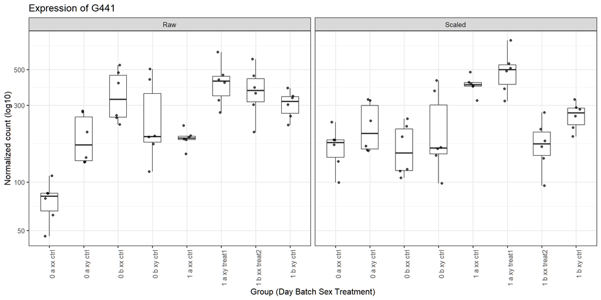

## Limma and comBat-seq

These next steps create other DDS objects to compare with the single batch correction using a similar method (as seen in “DESeq2-MultiBatch: Batch Correction for Multi-Factorial RNA-seq Experiments”) and popular tools for RNA-seq pipelines.

First, a new colData is created, which uses a different notation for batches : samples from batch A are still “A”, and females from batch B are still “B”, but males from batch B are now “C”.

```r
colData_abc <- colData
colData_abc$Batch <- as.character(colData_abc$Batch)
colData_abc$Batch <- ifelse(colData_abc$Sex == "xy" & colData_abc$Batch == "b", "c", colData_abc$Batch)
colData_abc$Batch <- as.factor(colData_abc$Batch)
```

This colData format allows comBat-seq and limma to provide a similar batch correction as MultiBatch.

The intuitive A/B batch notation, which better reflects the experimental setup, only allows for a single batch correction that does not include an interaction term, to my knowledge. Using A, B and C provides factors to compare B and A, then C and A independently.

## Single correction

This single correction is similar to the one applied previously, although it averages both batches instead of correcting counts of batch B only.

```r
# Construct the design
design_single <- ~ Day + Batch + Genotype + Sex + Sex:Day + Treatment

# construct a DESeqDataSet object
dds_single <- DESeqDataSetFromMatrix(countData = counts,
                                  colData = colData,
                                  design = design_single)

# Run DESeq
dds_single <- DESeq(dds_single)
```

```r
resultsNames(dds_single)
```

```
## [1] "Intercept"                "Day_1_vs_0"
## [3] "Batch_b_vs_a"             "Genotype_c2_vs_c1"
## [5] "Sex_xy_vs_xx"             "Treatment_treat1_vs_ctrl"
## [7] "Treatment_treat2_vs_ctrl" "Day1.Sexxy"
```

```r
batch <- results(dds_single, name = "Batch_b_vs_a", independentFiltering = FALSE)
batch <- as.data.frame(batch)

batch$Scaling_Factor_Batch_A <- sqrt(2^(batch$log2FoldChange))
batch$Scaling_Factor_Batch_B <- 1 / batch$Scaling_Factor_Batch_A
normalized_counts_df <- as.data.frame(counts(dds_single, normalized = TRUE))
scaled_counts_single <- normalized_counts_df

for (Sample_ID in colnames(normalized_counts_df)) {

  Batch <- colData[Sample_ID, "Batch"]

  if (Batch == "a") {
    scaling_factors <- batch$Scaling_Factor_Batch_A
  } else if (Batch == "b") {
    scaling_factors <- batch$Scaling_Factor_Batch_B
  }

  scaled_counts_single[, Sample_ID] <- normalized_counts_df[, Sample_ID] * scaling_factors
}

scaled_counts_single <- round(scaled_counts_single)
```

```r
design_nobatch <- ~ Day + Genotype + Sex + Sex:Day + Treatment
design_matrix_nobatch <- model.matrix(design_nobatch, data = colData)

dds_new <- DESeqDataSetFromMatrix(countData = round(normalized_counts_df),
                                  colData = colData,
                                  design = design_nobatch)

dds_single_nobatch <- DESeqDataSetFromMatrix(countData = scaled_counts_single,
                                  colData = colData,
                                  design = design_nobatch)

dds_double_nobatch <- DESeqDataSetFromMatrix(countData = scaled_counts,
                                  colData = colData,
                                  design = design_nobatch)

vsd_new <- vst(dds_new, blind = FALSE)
vsd_scaled_single <- vst(dds_single_nobatch, blind = FALSE)
vsd_scaled_double <- vst(dds_double_nobatch, blind = FALSE)

vsd_matrix <- assay(vsd_new)

# use limma
vsd_limma_matrix <- removeBatchEffect(vsd_matrix, batch = colData$Batch, design = design_matrix_nobatch)
vsd_limma_matrix_abc <- removeBatchEffect(vsd_matrix, batch = colData_abc$Batch, design = design_matrix_nobatch)

vsd_limma <- vsd_new
vsd_limma_abc <- vsd_new
assay(vsd_limma) <- vsd_limma_matrix
assay(vsd_limma_abc) <- vsd_limma_matrix_abc

# use combat
combat_data <- ComBat_seq(counts = as.matrix(round(normalized_counts_df)), batch = colData$Batch, covar_mod = design_matrix_nobatch, full_mod = TRUE)
```

```
## Found 2 batches
## Using null model in ComBat-seq.
## Adjusting for 6 covariate(s) or covariate level(s)
## Estimating dispersions
## Fitting the GLM model
## Shrinkage off - using GLM estimates for parameters
## Adjusting the data
```

```r
combat_data_abc <- ComBat_seq(counts = as.matrix(round(normalized_counts_df)), batch = colData_abc$Batch, covar_mod = design_matrix_nobatch, full_mod = TRUE)
```

```
## Found 3 batches
## Using null model in ComBat-seq.
## Adjusting for 6 covariate(s) or covariate level(s)
## Estimating dispersions
## Fitting the GLM model
## Shrinkage off - using GLM estimates for parameters
## Adjusting the data
```

```r
dds_combat <- DESeqDataSetFromMatrix(countData = combat_data,
                                  colData = colData,
                                  design = design_nobatch)

dds_combat_abc <- DESeqDataSetFromMatrix(countData = combat_data_abc,
                                  colData = colData,
                                  design = design_nobatch)

vsd_combat_single <- vst(dds_combat, blind = FALSE)
vsd_combat_double <- vst(dds_combat_abc, blind = FALSE)
```

# Ressources

https://github.com/csoneson/ExploreModelMatrix Interactive exploration of design matrices with ExploreModelMatrix Charlotte Soneson, Federico Marini, Michael I Love, Florian Geier and Michael B Stadler

ExploreModelMatrix: Interactive exploration for improved understanding of design matrices and linear models in R doi: 10.12688/f1000research.24187.2 Charlotte Soneson, Federico Marini, Michael I Love, Florian Geier and Michael B Stadler

https://github.com/tavareshugo/tutorial_DESeq2_contrasts Hugo Tavares (University of Cambridge, Bioinformatics Training Facility)

A guide to creating design matrices for gene expression experiments Charity W Law, Kathleen Zeglinski, Xueyi Dong, Monther Alhamdoosh, Gordon K Smyth, Matthew E Ritchie doi: 10.12688/f1000research.27893.1